# P =? NP

Tasaday Green and Allie Klump

4/30/2019

In this blog post, we explore Scott Aaronson’s 2016 paper on P =? NP and explain parts of his paper that we found most interesting.

#### Definition of the Problem

In simple terms, Aaronson describes the question does P equal NP as “[asking] whether there’s a fast procedure to answer all questions that have short answers that are easy to verify mechanically.” (Aaronson, 2016) For every single problem that has an easy way to verify it, can we also solve it quickly?

#### Some Background Information

First, let’s review some important complexity classes:

- P contains problems that can be solved in polynomial time.
- NP contains problems that can be verified in polynomial time. This means that given a possible solution to the problem, we can check if it is correct in polynomial time. P is a subset of NP
- NP-complete problems can be verified but not solved in polynomial time. They are at the intersection of NP and NP-hard.
- NP-hard problems are a bit more tricky to define. Essentially, this class contains problems that are “at least as hard as any NP problem.” To be more technical, a language is in NP-hard if every language in NP can be reduced to it.

Now let’s consider the consequences of P != NP compared to P = NP.

#### The Consequences of P != NP vs. P = NP: how the diagram “collapses”

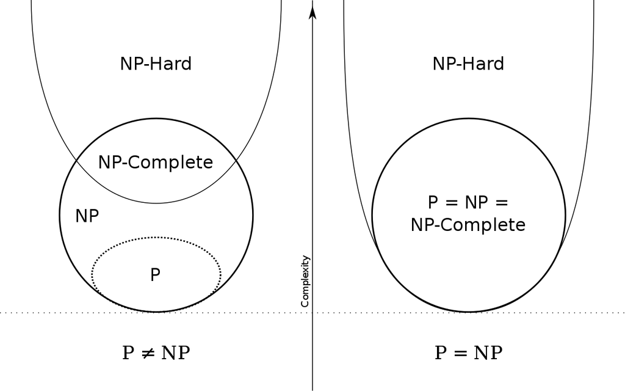

It is important to notice that in the diagram for P!=NP, NP does not appear to be a dichotomy. While P and NP-complete are both subsets of NP, not all problems in NP are also in either P or NP-complete. Are there actually any problems here?

#### The “Twilight Zone”: NP-intermediate

The answer is yes. A theorem by Ladner proves that if P != NP, then there exist NP-intermediate languages (listed as theorem 5 in the paper). This is the “twilight zone” of NP. While the NP-intermediate languages constructed by Ladner for the proof aren’t very useful, there are many real problems that are suspected to be NP-intermediate (e.g. some problems in cryptography, algebra, and number theory).

The existence of NP-intermediate problems is an interesting consequence of P != NP being true. But just looking at how the diagram changes is a very narrow perspective.

#### Robot Uprising?

[figure not shown]

To expand things a little, we can try equating P and NP-complete to different levels of creativity. Problems in P are simple, and uncreative, while problems in NP-complete are harder, more creative. Humans tend to be good at solving all types of problems, while machines are only good at solving uncreative problems.

[figure not shown]

If P = NP, there is a way of converting creative problems into uncreative problems, making them easier for machines to solve. What are the consequences of this in terms of, say, a robot uprising? If machines can solve creative problems quickly, we humans lose our advantage over them. However, we have to remember that even if P = NP, there are still NP-hard problems that are not in NP, and therefore can only be solved in a highly creative way. These are problems that machines would still not be able to solve efficiently, and so P = NP does not guarantee a robot uprising.

[figure not shown]

If P != NP, we can be sure that robots won’t be able to solve all NP problems in polynomial time. However, this alone won’t prevent a robot uprising. Machines only need to be more efficient at solving problems/smarter than us to take over the world. In summary, the answer to P =? NP wouldn’t provide any concrete answers on the possibility of a robot uprising, though it is interesting to think about.

#### Is Cryptography Doomed?

[figure not shown]

Something closer to the real world and more relevant to the present that would be affected by the answer to P =? NP is cryptography. Most cryptography relies on the existence of “one-way functions” (functions that are easy to compute but difficult to invert), which cannot exist if P = NP. While there are some more advanced types of cryptography that would not be affected by this result (e.g. quantum cryptography), most cryptography would be insecure. We could hope that even if P = NP is proved, an actual solution to convert NP-complete problems to P is hard to find, or if such a solution is found we could hope that it is very inefficient in practice (the exponent of the polynomial could be very large). But there would be great incentive to find a solution or improve an inefficient solution, and so it would be unwise to continue to operate as though most cryptography was secure.

On the other hand, if P != NP, then cryptography will still be okay for the time being. Technically, there are some other requirements that we need to be sure that most of cryptography is secure, but at least in a world of P != NP, most cryptography isn’t definitely not secure.

#### So Which Is It?

Now that we’ve covered some of the implications of P != NP vs. P = NP, let’s explore why we still don’t have a definitive answer.

The inherent difficulty of proving either P=NP or P!=NP has led to its inclusion in the Clay Millennium Problems which is a set of seven open mathematics problems considered to be the most difficult. Within this set there are questions that are over a century old such as the Riemann Hypothesis and the Poincare Conjecture. The nature of P =? NP is such that there are distinguishing implications of solving it. If one were able to prove that P = NP and find an efficient algorithm then one could in theory write an algorithm to find proofs corresponding to the other six problems and actually solve the entire set.

#### Most Computer Scientists Conjecture P != NP

Polling shows that the majority of mathematicians and computer scientists believe the conjecture that P != NP. One particular poll on 2002 showed 62 participants supporting the P != NP conjecture and 9 participants believing that P = NP. Even more perplexing, is the number of purported proofs of four separate cases. Case 1 in which P = NP has at last count 62 claimed proofs, case 2 in which P != NP has 50 claimed proofs, case 3 which claims the problem is unprovable has 2 alleged proofs, and case 4 which claims the problem is undecidable has 1.

In his paper, Scott Aaronson writes, “If computer scientists had been physicists, we’d simply have declared P! = NP to be observed as a law of Nature, analogous to the laws of thermodynamics.” This sentiment is a consequence of the fact that observations support P != NP. For example, while thousands of problems have been shown to be NP-complete or have been shown to be in P, the presence of a single language that is in both would imply P = NP. However, not one such problem has been identified. In other words, the opportunity to potentially falsify P != NP has arisen many many times and still has not occured. To many this is the basis for an intuitive argument for P != NP.

Another somewhat intuitive approach looks at the existing theorems regarding the hierarchy of complexity class and makes note that most complexity classes are not equal and so P is likely not equal to NP. It is important to note that the caveat that while such classes are generally not equal it is not always possible to prove for a given pair of classes.

#### Why is Proving P != NP So Difficult?

Aaronson uses the phrase “symmetry of ignorance” to describe the current situation. This encapsulates the main issues. On one hand, no one knows how to solve NP-complete problems in polynomial-time and on the other hand, no one knows how to prove that it cannot be done. There are three main technical barriers to proving P != NP. The relativization barrier is related to the techniques used in proving theorems in complexity theory and their level of generality. In this case the issue is that the existing techniques are too general. The algebrization barrier is similar but modified. The natural proof barrier relates to random restriction and polynomial methods being insufficient to prove P != NP. Although, each barrier taken individually is able to be surmounted we do not yet have the methods to deal with all barriers at once.

[figure not shown]

The difficulties resulting from these barriers against finding a truly sound proof of P != NP have led to questions regarding whether or not the currently held axioms are sufficient to find the proof at all. Consider that axioms are statements that are taken to be true and form the foundation of mathematics and in turn computer science. Axioms are used as premises to logically build out from to create a growing structure of theorems. A true proof is a logical argument that can be inferred from accepted axioms. To question whether the standard axioms are sufficient is to suggest the possibility that either the held axioms are flawed, there are yet undiscovered sets of axioms inside the known structure, or there are yet undiscovered axioms outside of the known structure that exist independently.

*What each of us contributed: Tasaday came up with the topic, and Allie found the paper. We both read the paper and constructed an outline of possible topics within the paper to cover. We each talked/wrote about the parts of the paper we found most interesting.*

**Sources:**

- Paper: https://www.scottaaronson.com/papers/pvsnp.pdf
- P != NP vs. P = NP diagram: by Behnam Esfahbod, CC BY-SA 3.0, https://commons.wikimedia.org/w/index.php?curid=3532181
- Comics, in order of appearance:
  - https://xkcd.com/1968/
  - https://condenaststore.com/featured/new-yorker-march-6th-2017-roz-chast.html
  - https://xkcd.com/329/
  - https://xkcd.com/538/
  - https://xkcd.com/1724/